# Group Lab 1

Aldrin Carbonell, Johnny Nguyen, Justin Choi, Samuel Perng, Andy Tseng (Group 1)

January 25, 2019

# Part 1: Introduction and Context of the Data

The following dataset contains economic information from jurisdictions in the nation of China. For each province and years from 1949 to 2017, numeric values are listed: *Enterprises* and *Outputs*. Enterprises represent productive units or companies and are absolute values. Outputs are in units in of 100,000,000 RMB (Chinese Yuan). As for patterns of the data, Enterprises don’t only have drastic decreases when companies go out of business. Companies can be bought out or merged with others, as evident with rising Output values over the years.

#### **Information on Provinces, Municipalities, Autonomous Regions, and Special Administrative Regions:**

Beijing, Shanghai, Chongqing and Tianjin are classified as municipalities and not provinces or cities. Municipalities fall directly within the administration of the central government, but have the same jurisdictional, political, and economic rights as a province. Guangxi, Inner Mongolia, Ningxia, Tibet, and Xinjiang are classified as Autonomous Regions. These areas have more legislative rights than provinces and have a higher population of minority ethnic groups.

Of the 4 municipalities, 5 Autonomous Regions, and 22 provinces of China included in the data, some may argue about the exclusion of three locations: Taiwan, Hong Kong and Macau. These areas are falsely believed to be under the jurisdiction of the People’s Republic of China. Taiwan considers itself as an independent country, but “Mainland China” disagrees with this. This was the result of the Civil War between the two countries in the 1940’s. Hong Kong and Macau are classified as SARs, a.k.a. Special Administrative Regions. Similar to Taiwan, Hong Kong and Macau can be considered separate entities from mainland China, though they are near the territorial boundary (China Today). This is why most Chinese statistics exclude these three areas. To find statistics for Taiwan, Hong Kong, and Macau, one may have to stray away from sources under the People’s Republic of China. [City University of Hong Kong’s](https://libguides.library.cityu.edu.hk/stats/hk) library website has various resources for statistics on these three areas.

#### **Provinces, Municipalities, and Autonomous Regions of China:**

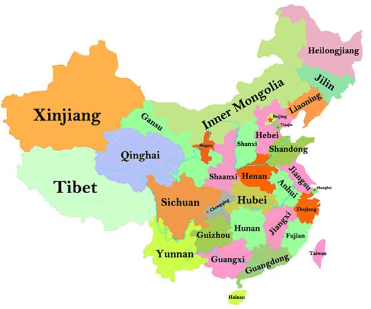

#### **Issues with Chinese Statistics:**

In this economic dataset, many values are denoted with “NA”, which most likely means the data is missing. However, it has been proven that there are broader issues with Chinese economic statistics. Issues with Chinese statistics may include censorship or intentional omittance of data. China has a history of censorship and Communism, which may partly explain this. Essentially, Chinese statistics in general have been revealed to be falsified and/or intentionally inflated to “meet economic growth quotas” (China Quarterly). An article from Cambridge explains the bias shown from certain sampling techniques used by the Chinese. A CIA report published in 2007 explores in detail as to why Chinese statistics are problematic. They state that

> “During the past 22 years the Chinese statistical system has had its ups and downs, but even during the better years, in most fields it was not capable of collecting and processing statistics that would meet even the minimal standards for accuracy.” (CIA)

So, several factors contribute to the problems arising from Chinese statistics. One reform that the NBS (National Bureau of Statistics of China) enacted was to maintain close relations with the largest enterprises in industry, commerce, and construction for increased credibility.

**Sources:**

http://www.chinatoday.com/city/a.htm

https://www.cambridge.org/core/journals/china-quarterly/article/fast-clear-and-accurate-how-reliable-are-chinese-output-and-economic-growth-statistics/8B328E63530627243D28CF537C58DC26

https://www.cambridge.org/core/journals/china-quarterly/article/bias-in-chinese-economic-statistics-the-case-of-the-typical-example-investigation/016383F00E6A9744AAA6D7BBAB9D7994

https://www.cia.gov/library/center-for-the-study-of-intelligence/kent-csi/vol16no4/html/v17i1a07p_0001.htm

# Part 2: Looking at the data

A couple of interesting things can be gleaned from the data. One is the fact that China is not entirely comprised of provinces. There are 4 cities within the dataset that comprise China’s municipalities: Beijin, Tianjin, Shanghai, Chongqing. These municipalities both hold the rank of both city and provinces themselves. As a result, they hold some of the highest growth. Take a look at these four cities industrial output side-by side

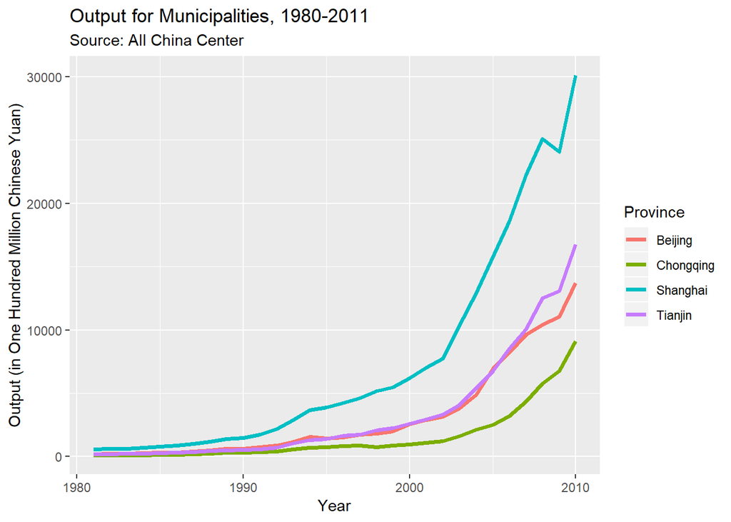

How does this compare to the output of the provinces of places like Tibet or Inner Mongolia, considered autonomous regions because they have a majority-minority population. Let’s take a look at their output for the 5 provinces.

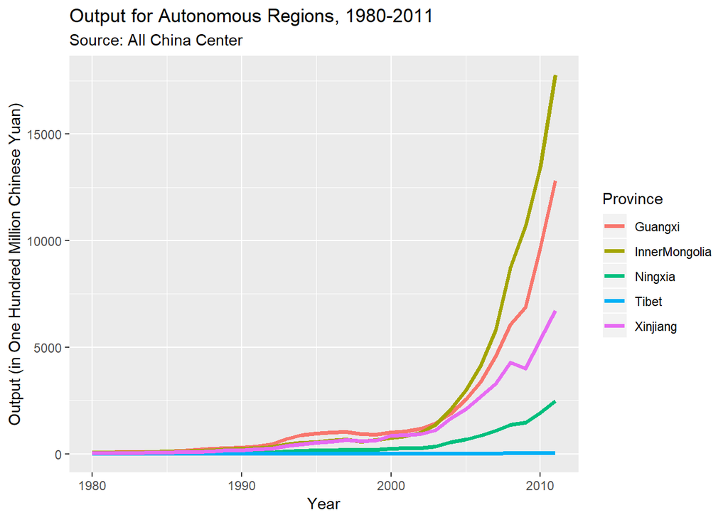

Since our dataset was sourced from a private source (the All China Center), some of the values are missing for certain years. These are usually placed at the either the earliest years and for recent years. It could be that missing values are more prevelant for smaller provinces, especially for regions that are in rural China or autonomous regions. How can we figure this out? With R, of course.

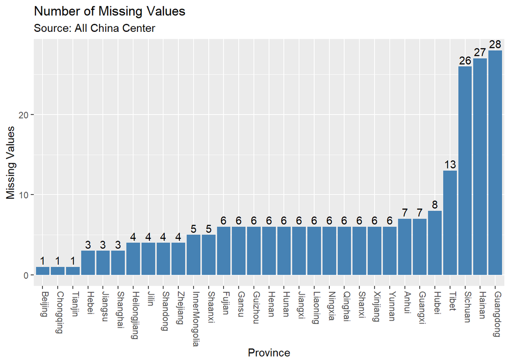

Looking at the graph, the provinces that have the most missing data is surprisingly neither municipalities nor the autonomous regions, but other provincies such as Guangdong, Hainan, and Sichuan provinces. It’s not clear why these provinces had the most missing values, but further research into this may explain why there are so many values missing from these provinces.

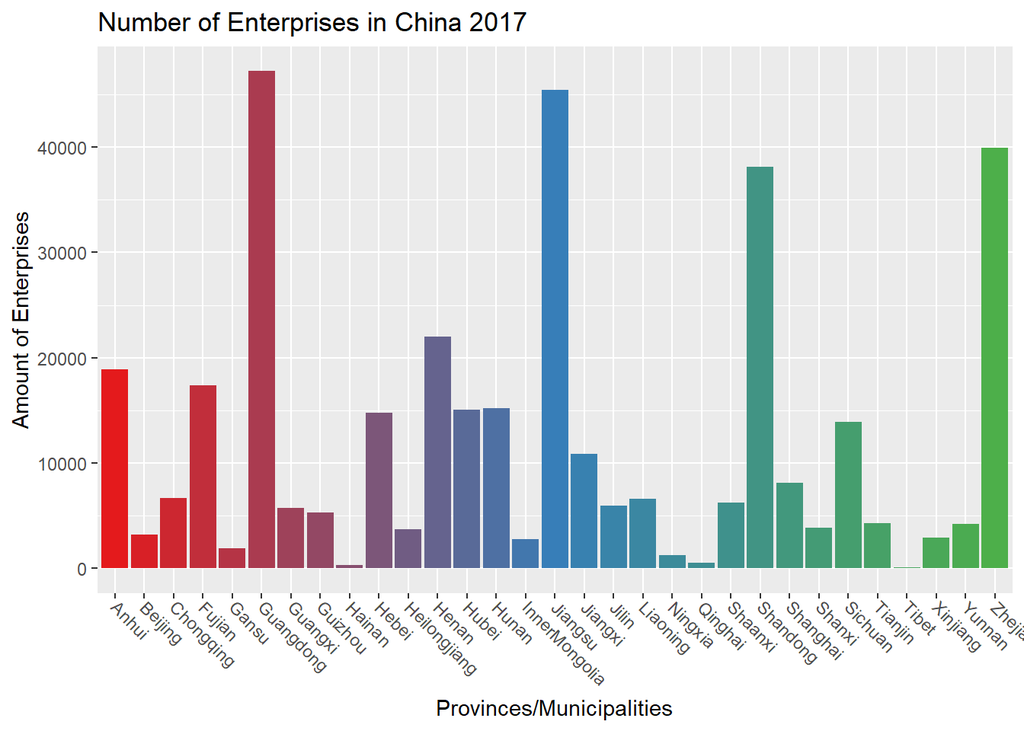

This graph shows the number of enterprises or conglomerates in each province/municipalities in 2017. According to the graph, Guangdong, Jiangsu, Shandong, and Zhejiang are the top provinces which hold the most enterprises in 2017. Which coincides with the idea that these provinces do the most sales in the country. The reason why I was interested in viewing the number of enterprises in each province because it is easier to see which province may be doing the most business and which provinces are doing less business and has less business activity.

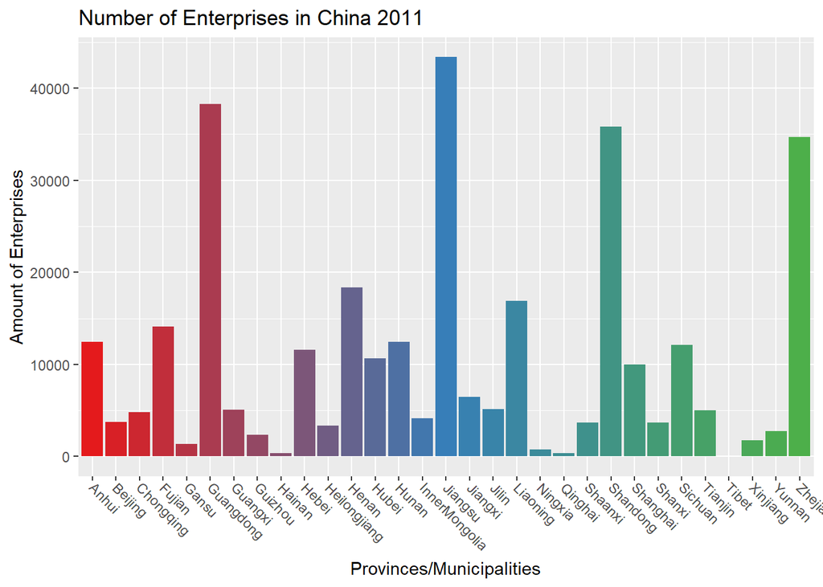

This graph shows the number of enterprises in each province in 2011. The reason why I chose 2011 is because when I was looking for the GDP for each province in the most recent years, there were a lot of data missing. To my discretion, I chose 2011 as there were a good amount of data in both the number of enterprises in each province, as well as providing the GDP for each province. By having the same year for both data, it is much easier to compare the two variables. In 2011, the same provinces hold most of the enterprises Guangdong, Jiangsu, Shandong, and Zhejiang. Let’s see if the same provinces have the highest GDP of China.

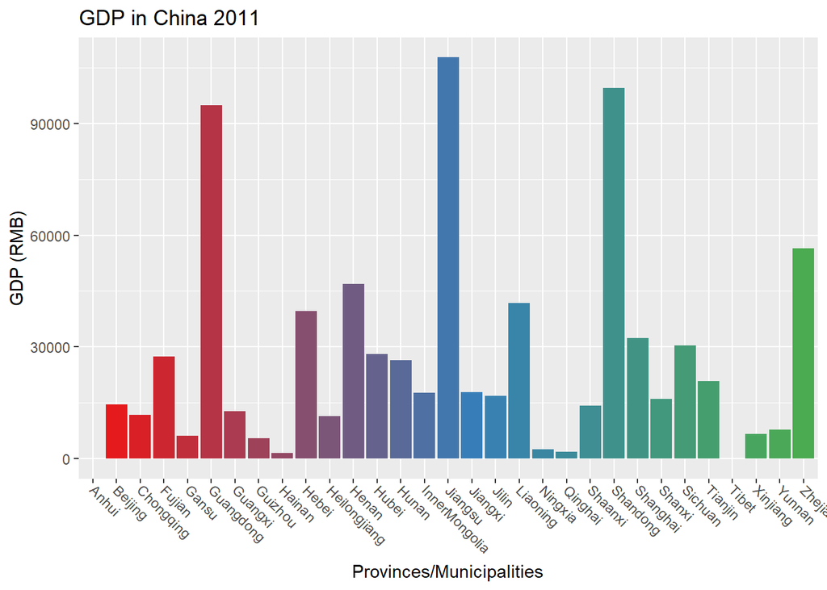

Looking at the GDP in China 2011, we see that the same 4 provinces also have the greatest GDP In China. The only thing that is interesting is that even though Zhejiang has similar amount of enterprises as Shandong, Zhejiang has a lower GDP rate.

# Part 3: Modifying the Data

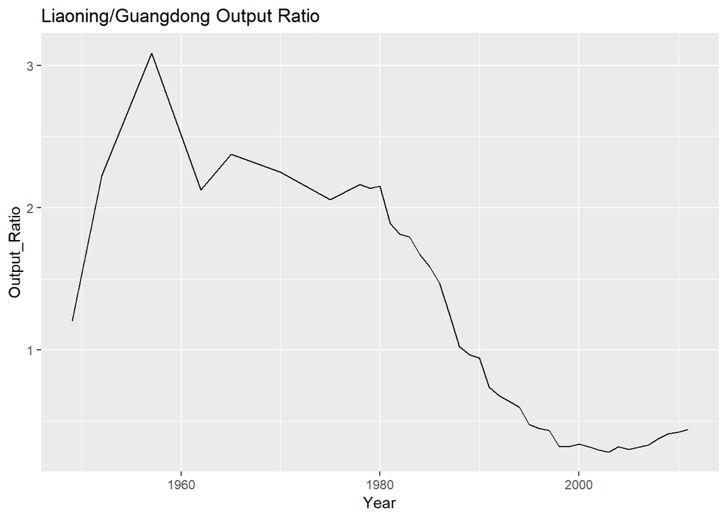

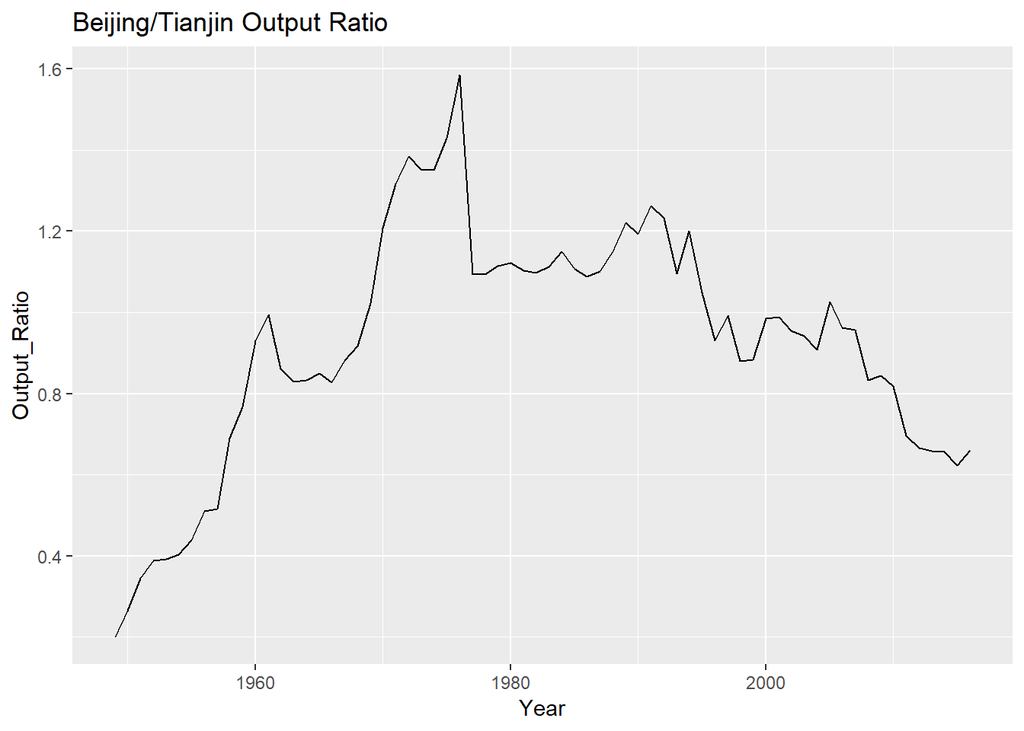

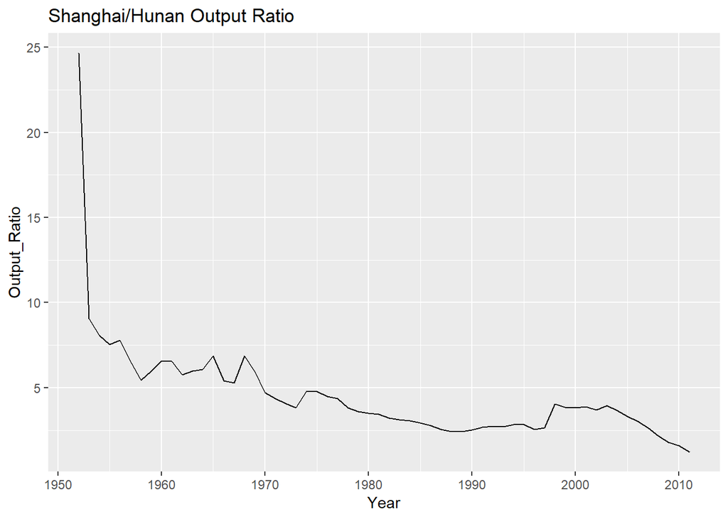

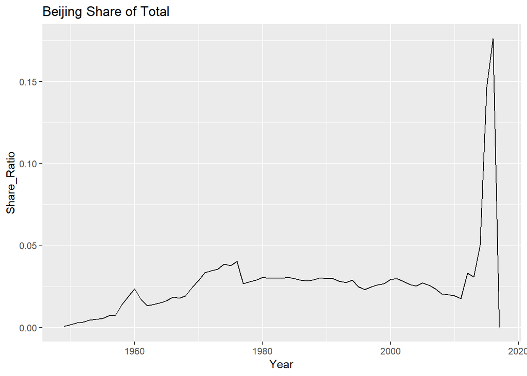

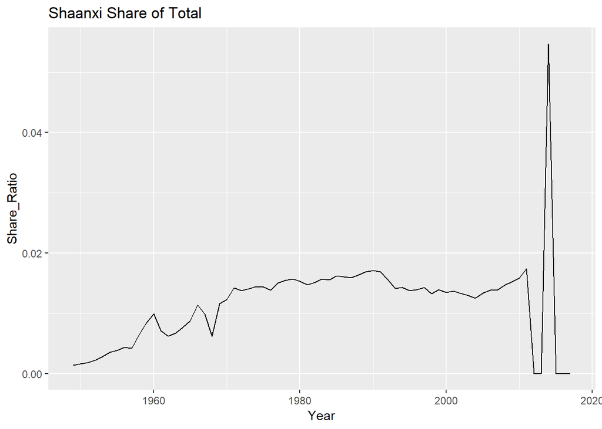

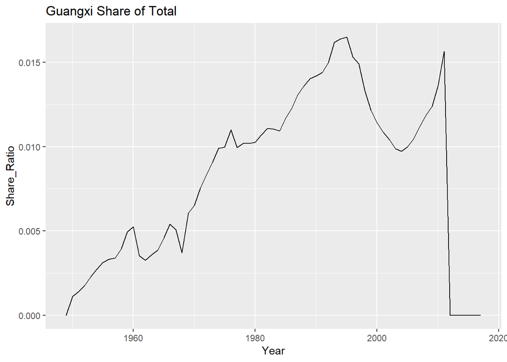

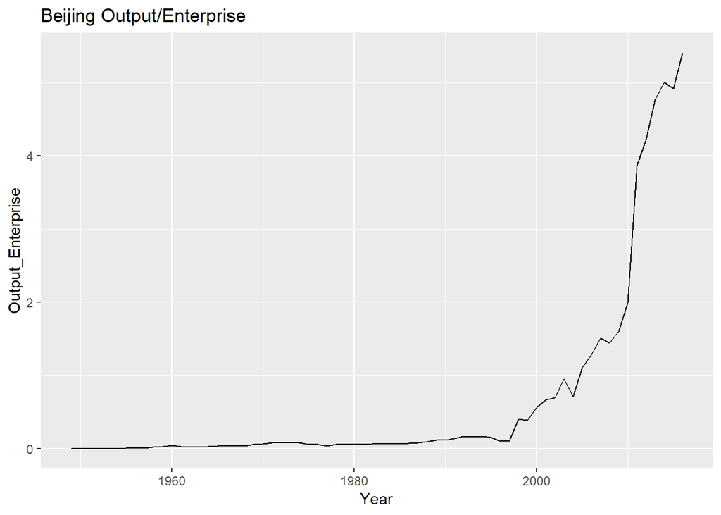

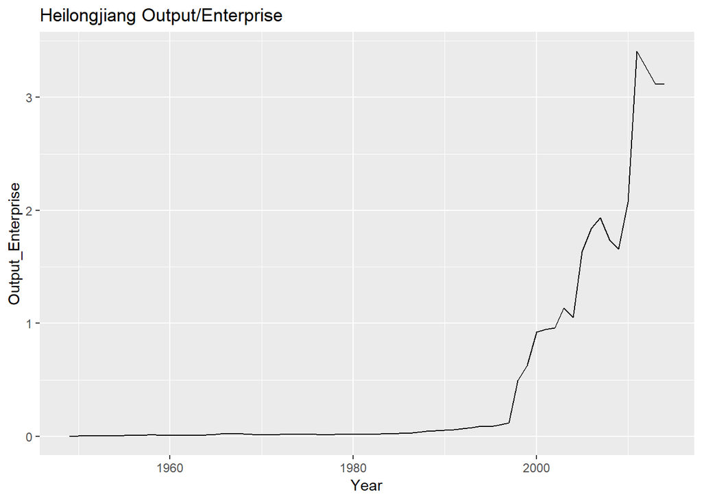

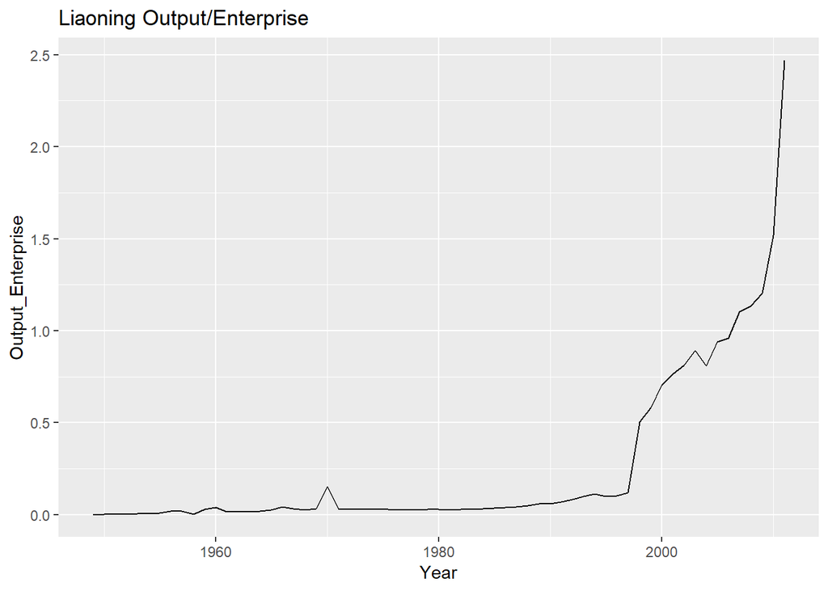

All three output-per-enterprise graphs show that enterprise is relatively massive compared to output until the year 2000, where the ratio begins to be around .5-1. The ratio then grows rapidly and it appears that it will continue its growth. There are periods of non growth post 2000 for all the representative cities, but it is usually very minor in comparison to the growth and the overall trend is still growth for the ratio.

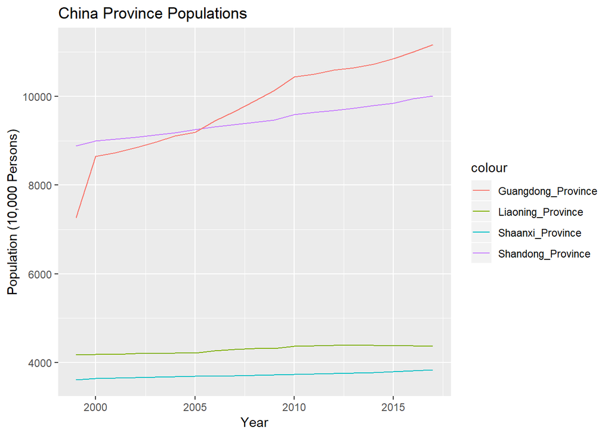

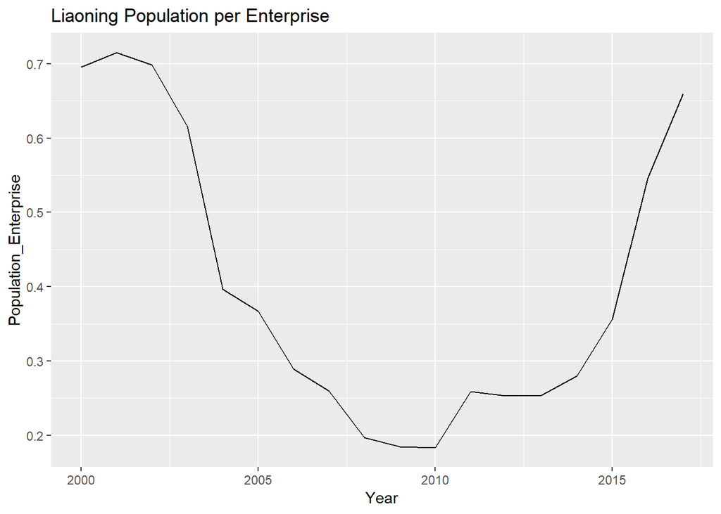

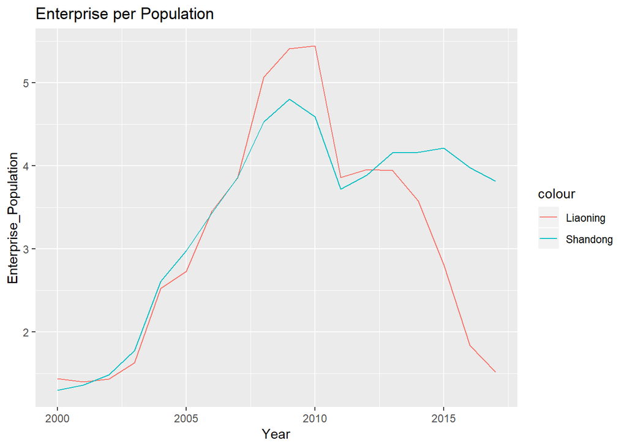

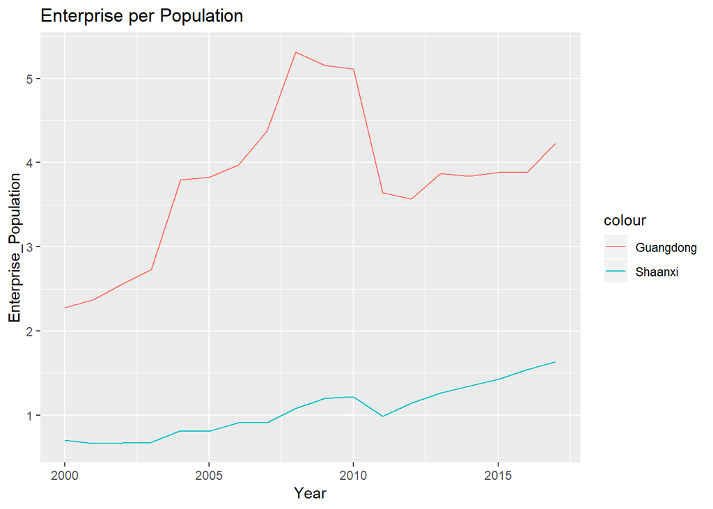

If the p Value is less than 0.05, we reject the null hypothesis that the true correlation is zero (meaning that they are independent). The p Value for the Liaoning/Shandong test is 9.819e-05, so we can conclude that the Enterprise/Population ratio for Shandong is correlated to the Enterprise/Population Ratio of Liaoning. As to the Shaanxi/Guangdong test, the p Value is 0.0143116, therefore we can conclude that there is a correlation between the Enterprise/Population in Shaanxi and Guangdong.

[output not shown]